# STAT452 Final Project - Task 2 - Fish

Luu Quoc Bao - 22125008, Le Minh Hoang - 22125029, Le Duc Nhuan - 22125070, Dang Minh Nhut - 22125071

2024-08-20

# Task 2.1

## 2.1.1 Intial setup

### Library

```r
library(ggplot2)
library(car)
library(faraway)
library(corrplot)
library(dplyr)
library(tidyr)
library(lmtest)
```

### Set seed

```r
set.seed(452)
```

## 2.1.2 Reading and preprocessing data

Data source: [kaggle](https://www.kaggle.com/datasets/vipullrathod/fish-market)

```r
df <- read.csv("Fish.csv", header = TRUE)
head(df)
```

```
##   Species Weight Length1 Length2 Length3  Height  Width
## 1   Bream    242    23.2    25.4    30.0 11.5200 4.0200
## 2   Bream    290    24.0    26.3    31.2 12.4800 4.3056
## 3   Bream    340    23.9    26.5    31.1 12.3778 4.6961
## 4   Bream    363    26.3    29.0    33.5 12.7300 4.4555
## 5   Bream    430    26.5    29.0    34.0 12.4440 5.1340
## 6   Bream    450    26.8    29.7    34.7 13.6024 4.9274
```

### Remove missing and duplicated rows

```r
sum(is.na(df))
```

```
## [1] 0
```

There is no missing values

```r
sum(duplicated(df))
```

```
## [1] 0
```

There is no duplicated rows

### Summary data

```r
dim(df)
```

```
## [1] 159   7
```

```r
summary(df)
```

```
##    Species              Weight          Length1         Length2
##  Length:159         Min.   :   0.0   Min.   : 7.50   Min.   : 8.40
##  Class :character   1st Qu.: 120.0   1st Qu.:19.05   1st Qu.:21.00
##  Mode  :character   Median : 273.0   Median :25.20   Median :27.30
##                     Mean   : 398.3   Mean   :26.25   Mean   :28.42
##                     3rd Qu.: 650.0   3rd Qu.:32.70   3rd Qu.:35.50
##                     Max.   :1650.0   Max.   :59.00   Max.   :63.40
##     Length3          Height           Width
##  Min.   : 8.80   Min.   : 1.728   Min.   :1.048
##  1st Qu.:23.15   1st Qu.: 5.945   1st Qu.:3.386
##  Median :29.40   Median : 7.786   Median :4.248
##  Mean   :31.23   Mean   : 8.971   Mean   :4.417
##  3rd Qu.:39.65   3rd Qu.:12.366   3rd Qu.:5.585
##  Max.   :68.00   Max.   :18.957   Max.   :8.142
```

There are total 159 rows and 7 columns in the data. The columns are “Species”, “Weight”, “Length1”, “Length2”, “Length3”, “Height”, and “Width”. “Species” is the only one qualitative variable, whereas the other 6 variables are quantitative. The description of each column according to the [data source](https://www.kaggle.com/datasets/vipullrathod/fish-market):

- `Species`: This column represents the species of the fish. It is a categorical variable that categorizes each fish into one of seven species. The species may include names like “Perch,” “Bream,” “Roach,” “Pike,” “Smelt,” “Parkki,” and “Whitefish.” This column is the target variable for the polynomial regression analysis, where we aim to predict the fish’s weight based on its other attributes.
- `Weight`: This column represents the weight of the fish. It is a numerical variable that is typically measured in grams. The weight is the dependent variable we want to predict using polynomial regression.
- `Length1`: This column represents the first measurement of the fish’s length. It is a numerical variable, typically measured in centimetres.
- `Length2`: This column represents the second measurement of the fish’s length. It is another numerical variable, typically measured in centimetres.
- `Length3`: This column represents the third measurement of the fish’s length. Similar to the previous two columns, it is a numerical variable, usually measured in centimetres.
- `Height`: This column represents the height of the fish. It is a numerical variable, typically measured in centimetres.
- `Width`: This column represents the width of the fish. Like the other numerical variables, it is also typically measured in centimetres.

### Combine length variables

Since Length1, Length2, and Length3 are the result of three different measure times, we will calculate the average of them to have the most accurate measurement.

```r
df$Length <- (df$Length1 + df$Length2 + df$Length3)/3
summary(df$Length)
```

```
##    Min. 1st Qu.  Median    Mean 3rd Qu.    Max.
##   8.233  20.983  27.267  28.630  36.000  63.467
```

Now we remove old columns of Length

```r
df$Length1 <- NULL
df$Length2 <- NULL
df$Length3 <- NULL
```

### Histograms and Plots

#### Distribution of Species

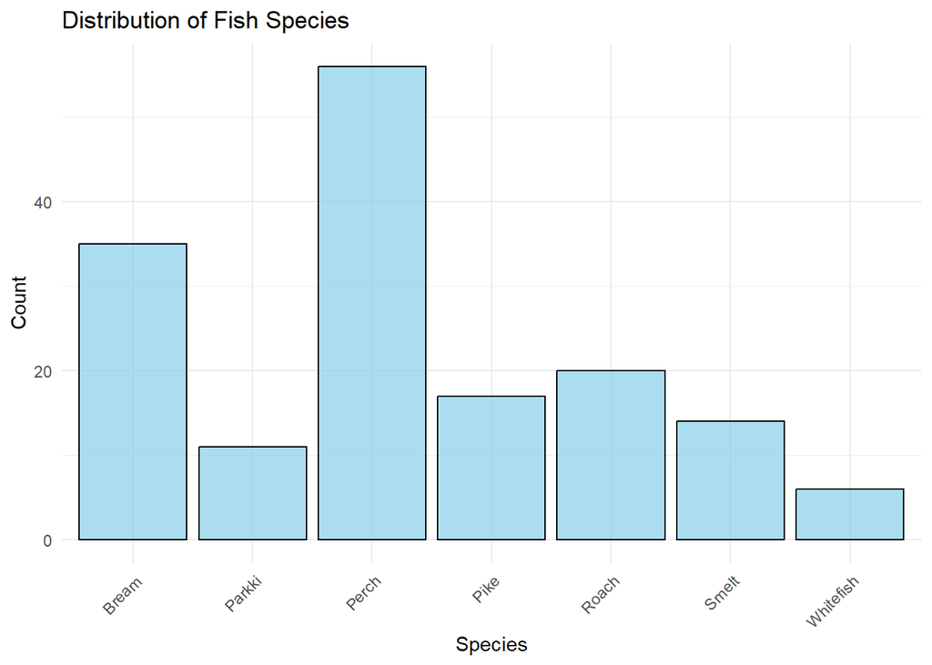

```r
ggplot(df, aes(x = Species)) +
  geom_bar(fill = "skyblue", color = "black", alpha = 0.7) +
  theme_minimal() +
  labs(title = "Distribution of Fish Species", x = "Species", y = "Count") +
  theme(axis.text.x = element_text(angle = 45, hjust = 1))
```

We can see that Perch and Bream have more appearance in the dataset than other species.

#### Histogram of numeric columns

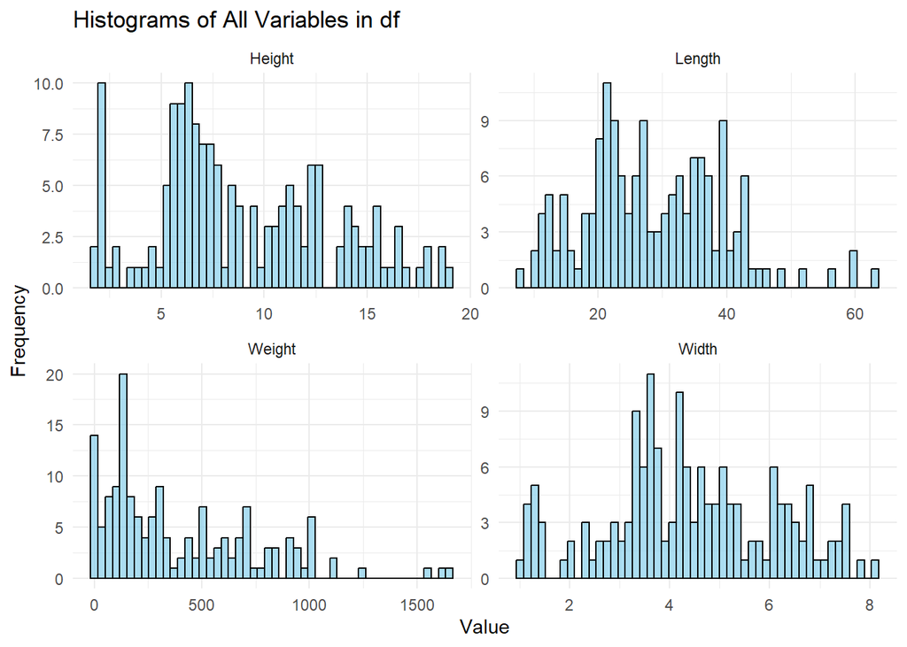

```r
df_long <- subset(df, select = -c(Species)) %>%
  pivot_longer(cols = everything(), names_to = "variable", values_to = "value")

# Plotting histograms for all variables
ggplot(df_long, aes(x = value)) +
  geom_histogram(fill = "skyblue", color = "black", alpha = 0.7, bins=50) +
  facet_wrap(~variable, scales = "free") +
  theme_minimal() +
  labs(title = "Histograms of All Variables in df", x = "Value", y = "Frequency")
```

The histograms are not “smooth”, so that seems like the distributions of length, height, and width are different among species. So we are going to research it.

#### Height by Species

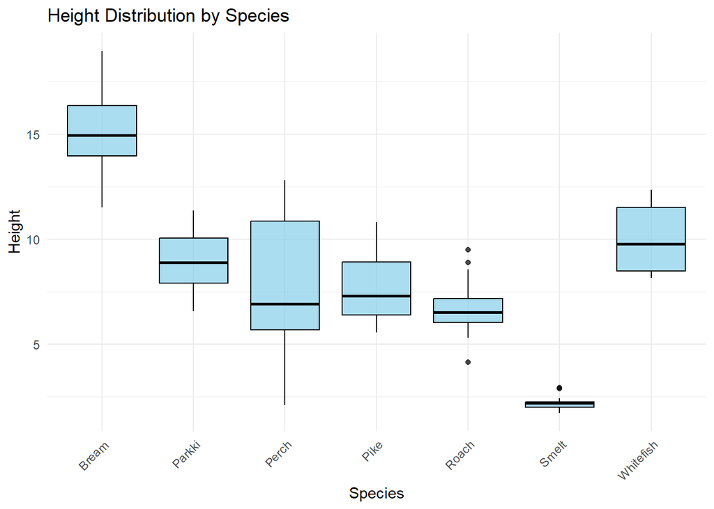

```r
ggplot(df, aes(x = Species, y = Height)) +
  geom_boxplot(fill = "skyblue", color = "black", alpha = 0.7) +
  theme_minimal() +
  labs(title = "Height Distribution by Species", x = "Species", y = "Height") +
  theme(axis.text.x = element_text(angle = 45, hjust = 1))
```

The boxplot suggests that Parkki, Perch, Pike, and Roach species has relatively small different in height. On the other hand, Smelt seems to have the smallest height, and Bream has largest height.

#### Width by Species

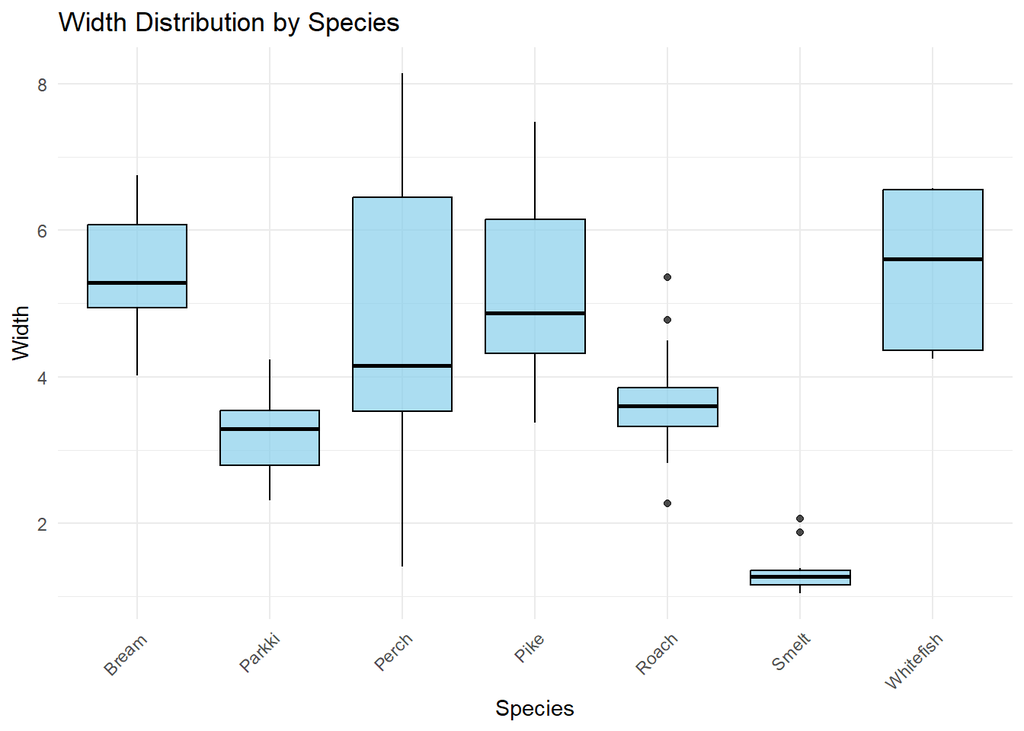

```r
ggplot(df, aes(x = Species, y = Width)) +
  geom_boxplot(fill = "skyblue", color = "black", alpha = 0.7) +
  theme_minimal() +
  labs(title = "Width Distribution by Species", x = "Species", y = "Width") +
  theme(axis.text.x = element_text(angle = 45, hjust = 1))
```

The boxplot suggests that Bream, Pike, and Whitefish species have the largest width. On the other hand, Smelt has the smallest width.

#### Length by Species

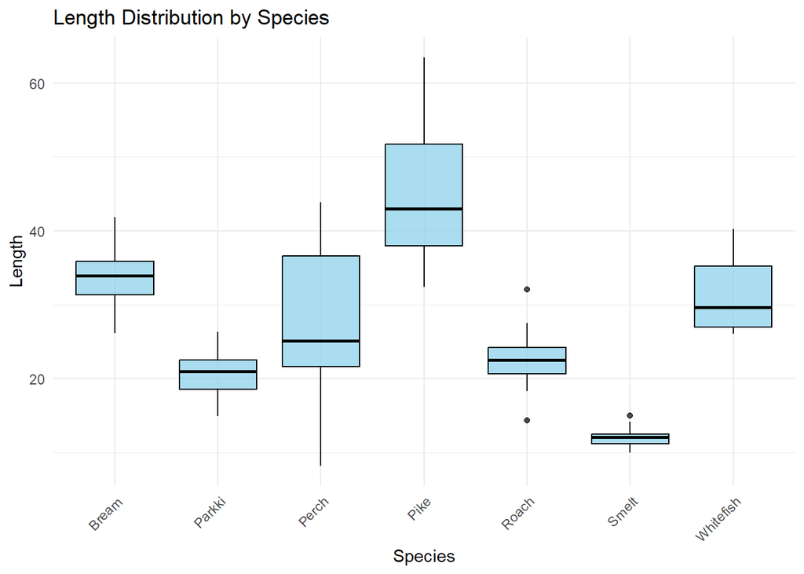

```r
ggplot(df, aes(x = Species, y = Length)) +
  geom_boxplot(fill = "skyblue", color = "black", alpha = 0.7) +
  theme_minimal() +
  labs(title = "Length Distribution by Species", x = "Species", y = "Length") +
  theme(axis.text.x = element_text(angle = 45, hjust = 1))
```

The boxplot suggests that Pike species has the largest length. On the other hand, Smelt has the smallest width.

#### Weight by Species

From 3 diagrams above, we can expect that Smelt is the smallest fish and hence has the smallest weight. And Pike, Bream might have the largest weight, since their size measurements are larger than the others.

The following boxplot confirms that.

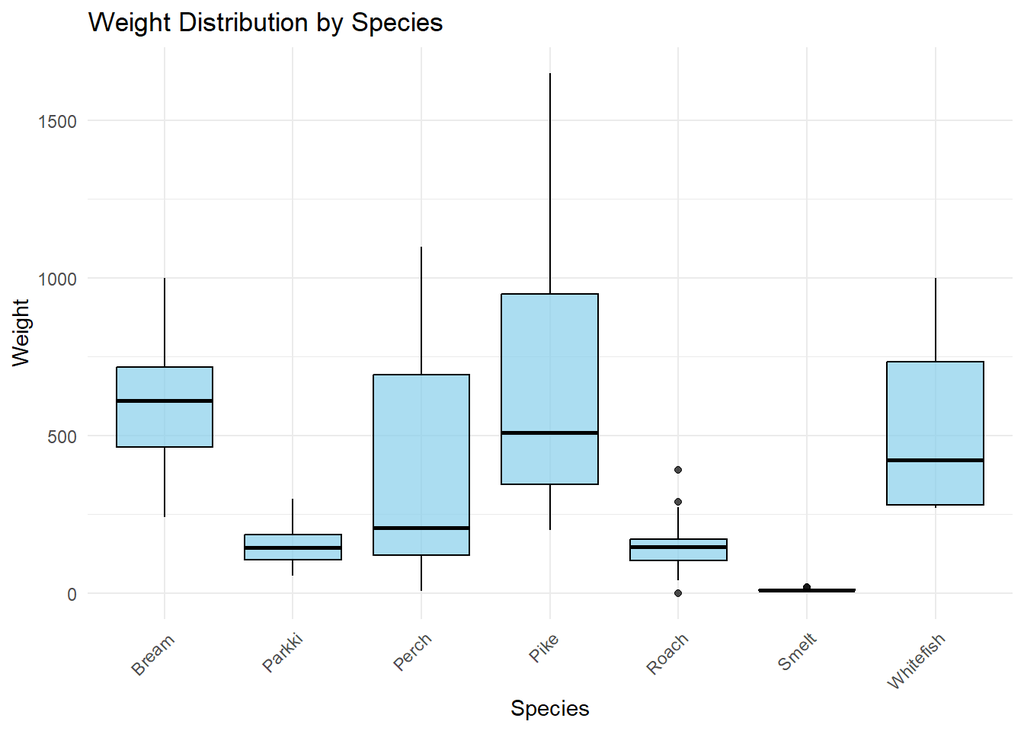

```r
ggplot(df, aes(x = Species, y = Weight)) +
  geom_boxplot(fill = "skyblue", color = "black", alpha = 0.7) +
  theme_minimal() +
  labs(title = "Weight Distribution by Species", x = "Species", y = "Weight") +
  theme(axis.text.x = element_text(angle = 45, hjust = 1))
```

#### Boxplots and outliers detection

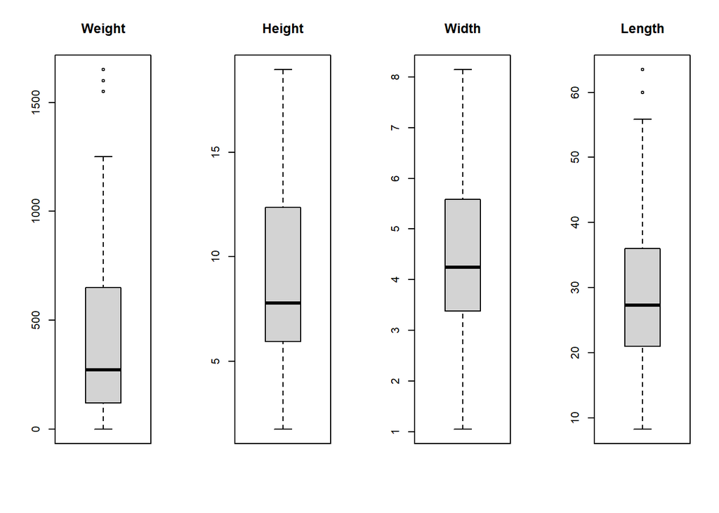

```r
par(mfrow = c(1, 4))

for (col in names(df)) {
  if (is.numeric(df[[col]]))
    boxplot(df[col], main = col)
}
```

```r
par(mfrow = c(1, 1))
```

The box plots suggest that there are not many outliers in the variables’ distributions. So we will not process any outliers removal.

## 2.1.3 Data splitting

### Convert Species to factor

We convert Species to factor allowing the linear regression model to use each separate value of the column as an independent variable. Since each Species may have unique signatures that affects the Weight.

```r
df$Species <- as.factor(df$Species)
```

### Split

We split the data into training and testing sets. The ratio of the training set to the testing set is 80:20.

```r
# Define the split ratio
train_ratio <- 0.8

# Determine the number of rows in the training set
train_size <- floor(train_ratio * nrow(df))

# Randomly sample row indices for the training set
train_indices <- sample(seq_len(nrow(df)), size = train_size)

# Split the data into training and testing sets
train_set <- df[train_indices, ]
test_set <- df[-train_indices, ]

# Display the number of rows in each set
dim(train_set) # Should be approximately 80
```

```
## [1] 127   5
```

```r
dim(test_set)  # Should be approximately 20
```

```
## [1] 32  5
```

## 2.1.4 Model fitting

### Baseline model

We fit a linear regression model with all original variables to predict “Weight”.

```r
model1_baseline <- lm(Weight ~ ., data = train_set)
summary(model1_baseline)
```

```
##
## Call:
## lm(formula = Weight ~ ., data = train_set)
##
## Residuals:
##     Min      1Q  Median      3Q     Max
## -188.78  -59.95  -12.47   41.93  392.09
##
## Coefficients:
##                  Estimate Std. Error t value Pr(>|t|)
## (Intercept)      -724.248     96.949  -7.470 1.57e-11 ***
## SpeciesParkki      47.126     55.515   0.849   0.3977
## SpeciesPerch       15.997     93.405   0.171   0.8643
## SpeciesPike      -310.276    138.737  -2.236   0.0272 *
## SpeciesRoach      -14.970     85.904  -0.174   0.8620
## SpeciesSmelt      261.517    103.186   2.534   0.0126 *
## SpeciesWhitefish   34.997     88.358   0.396   0.6928
## Height              4.020     14.926   0.269   0.7882
## Width              -2.786     26.556  -0.105   0.9166
## Length             38.562      4.050   9.522 2.92e-16 ***
## ---
## Signif. codes:  0 '***' 0.001 '**' 0.01 '*' 0.05 '.' 0.1 ' ' 1
##
## Residual standard error: 96.43 on 117 degrees of freedom
## Multiple R-squared:  0.9349, Adjusted R-squared:  0.9299
## F-statistic: 186.7 on 9 and 117 DF,  p-value: < 2.2e-16
```

The T tests for significant of each variables show that there is some insignificant variables that we can remove.

### Multicollinearity

We now check for multicollinearity to consider removing highly correlated variables.

#### Correlation matrix

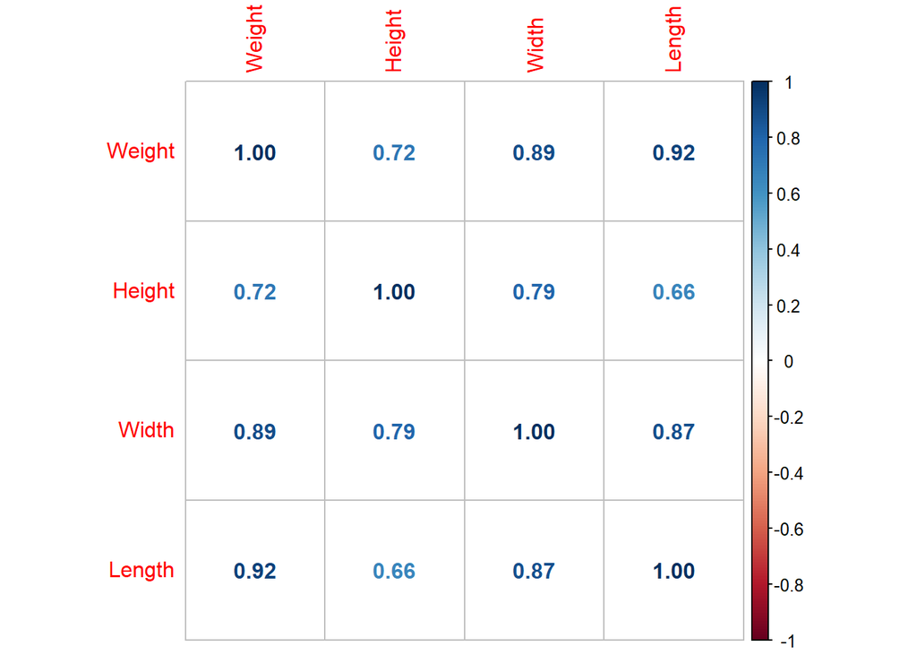

```r
corrplot(cor(subset(df, select = -Species)), method = "number")
```

We can see that Length is highly correlated to Width (0.87), so we should consider removing one of them from the model.

#### VIF scores

We calculate the Variance Inflation Factor (VIF) of the variables.

```r
vif(model1_baseline)
```

```
##    SpeciesParkki     SpeciesPerch      SpeciesPike     SpeciesRoach
##         2.484358        27.525786        24.154031        12.259670
##     SpeciesSmelt SpeciesWhitefish           Height            Width
##        11.504001         4.032523        54.252460        27.274494
##           Length
##        26.122066
```

“Height” variable has the highest VIF value and greater than 10. Therefore, we will remove it from the model.

```r
model1_vif<-update(model1_baseline, . ~ . -Height)
vif(model1_vif)
```

```
##    SpeciesParkki     SpeciesPerch      SpeciesPike     SpeciesRoach
##         1.423792         2.136882         4.641629         1.780962
##     SpeciesSmelt SpeciesWhitefish            Width           Length
##         2.157325         1.204515        16.814004        22.307629
```

“Length” variable has the highest VIF value and greater than 10. Therefore, we will remove it from the model.

```r
model1_vif<-update(model1_vif, . ~ . -Length)
vif(model1_vif)
```

```
##    SpeciesParkki     SpeciesPerch      SpeciesPike     SpeciesRoach
##         1.392761         1.848802         1.351528         1.695224
##     SpeciesSmelt SpeciesWhitefish            Width
##         2.155900         1.146551         1.854736
```

### First degree model

```r
summary(model1_vif)
```

```
##
## Call:
## lm(formula = Weight ~ Species + Width, data = train_set)
##
## Residuals:
##     Min      1Q  Median      3Q     Max
## -303.24  -65.77   -8.57   40.56  633.44
##
## Coefficients:
##                  Estimate Std. Error t value Pr(>|t|)
## (Intercept)      -491.485     57.800  -8.503 6.33e-14 ***
## SpeciesParkki     -27.265     57.225  -0.476  0.63463
## SpeciesPerch     -107.686     33.327  -3.231  0.00159 **
## SpeciesPike       189.442     45.181   4.193 5.32e-05 ***
## SpeciesRoach     -111.181     43.978  -2.528  0.01278 *
## SpeciesSmelt      224.506     61.498   3.651  0.00039 ***
## SpeciesWhitefish  -95.265     64.864  -1.469  0.14456
## Width             206.478      9.534  21.657  < 2e-16 ***
## ---
## Signif. codes:  0 '***' 0.001 '**' 0.01 '*' 0.05 '.' 0.1 ' ' 1
##
## Residual standard error: 132.8 on 119 degrees of freedom
## Multiple R-squared:  0.8745, Adjusted R-squared:  0.8671
## F-statistic: 118.5 on 7 and 119 DF,  p-value: < 2.2e-16
```

```r
model1_step <- step(model1_baseline, direction="backward")
```

```
## Start:  AIC=1170.07
## Weight ~ Species + Height + Width + Length
##
##           Df Sum of Sq     RSS    AIC
## - Width    1       102 1088090 1168.1
## - Height   1       675 1088663 1168.2
## <none>                 1087988 1170.1
## - Species  6    787866 1875854 1227.2
## - Length   1    843119 1931107 1240.9
##
## Step:  AIC=1168.08
## Weight ~ Species + Height + Length
##
##           Df Sum of Sq     RSS    AIC
## - Height   1       630 1088720 1166.2
## <none>                 1088090 1168.1
## - Species  6    866856 1954947 1230.5
## - Length   1   1044134 2132224 1251.5
##
## Step:  AIC=1166.15
## Weight ~ Species + Length
##
##           Df Sum of Sq      RSS    AIC
## <none>                  1088720 1166.2
## - Species  6   1209473  2298194 1249.0
## - Length   1   9275732 10364453 1450.3
```

```r
summary(model1_step)
```

```
##
## Call:
## lm(formula = Weight ~ Species + Length, data = train_set)
##
## Residuals:
##     Min      1Q  Median      3Q     Max
## -187.91  -59.12  -12.17   41.49  392.14
##
## Coefficients:
##                  Estimate Std. Error t value Pr(>|t|)
## (Intercept)      -701.863     45.731 -15.348  < 2e-16 ***
## SpeciesParkki      37.441     41.673   0.898    0.371
## SpeciesPerch       -7.586     24.774  -0.306    0.760
## SpeciesPike      -347.719     35.781  -9.718  < 2e-16 ***
## SpeciesRoach      -36.142     32.360  -1.117    0.266
## SpeciesSmelt      235.816     43.557   5.414 3.25e-07 ***
## SpeciesWhitefish   15.896     46.754   0.340    0.734
## Length             39.257      1.233  31.841  < 2e-16 ***
## ---
## Signif. codes:  0 '***' 0.001 '**' 0.01 '*' 0.05 '.' 0.1 ' ' 1
##
## Residual standard error: 95.65 on 119 degrees of freedom
## Multiple R-squared:  0.9349, Adjusted R-squared:  0.931
## F-statistic:   244 on 7 and 119 DF,  p-value: < 2.2e-16
```

The T test of SpeciesPike, SpeciesSmelt align with our expectation since these two species have the most significant different in “Weight” among all species.

```r
anova(model1_vif, model1_baseline)
```

```
## Analysis of Variance Table
##
## Model 1: Weight ~ Species + Width
## Model 2: Weight ~ Species + Height + Width + Length
##   Res.Df     RSS Df Sum of Sq      F    Pr(>F)
## 1    119 2097406
## 2    117 1087988  2   1009418 54.275 < 2.2e-16 ***
## ---
## Signif. codes:  0 '***' 0.001 '**' 0.01 '*' 0.05 '.' 0.1 ' ' 1
```

The p-value of the ANOVA test is much less than the significance level of 0.05, indicating that the removed variables are significant, so we should not use `model1_vif`.

```r
anova(model1_step, model1_baseline)
```

```
## Analysis of Variance Table
##
## Model 1: Weight ~ Species + Length
## Model 2: Weight ~ Species + Height + Width + Length
##   Res.Df     RSS Df Sum of Sq      F Pr(>F)
## 1    119 1088720
## 2    117 1087988  2    732.28 0.0394 0.9614
```

The p-value of the ANOVA test is much higher than the significance level of 0.05, indicating that the removed variables are not significant, and we can use `model1_step`.

```r
model1 <- model1_step
```

#### Model testing

```r
predictions <- predict(model1, newdata = test_set)
# Actual values from the test set
actual_values <- test_set$Weight
# Calculate Mean Squared Error (MSE)
mse <- mean((predictions - actual_values)^2)
# Calculate R-squared
rss <- sum((predictions - actual_values)^2)
tss <- sum((actual_values - mean(actual_values))^2)
r_squared <- 1 - (rss / tss)
# Print metrics
cat("R-squared:", r_squared, "\n")
```

```
## R-squared: 0.9160474
```

#### Model diagnostics

##### Normality of residuals

We now plot the Q-Q plot of the residuals to check for normality.

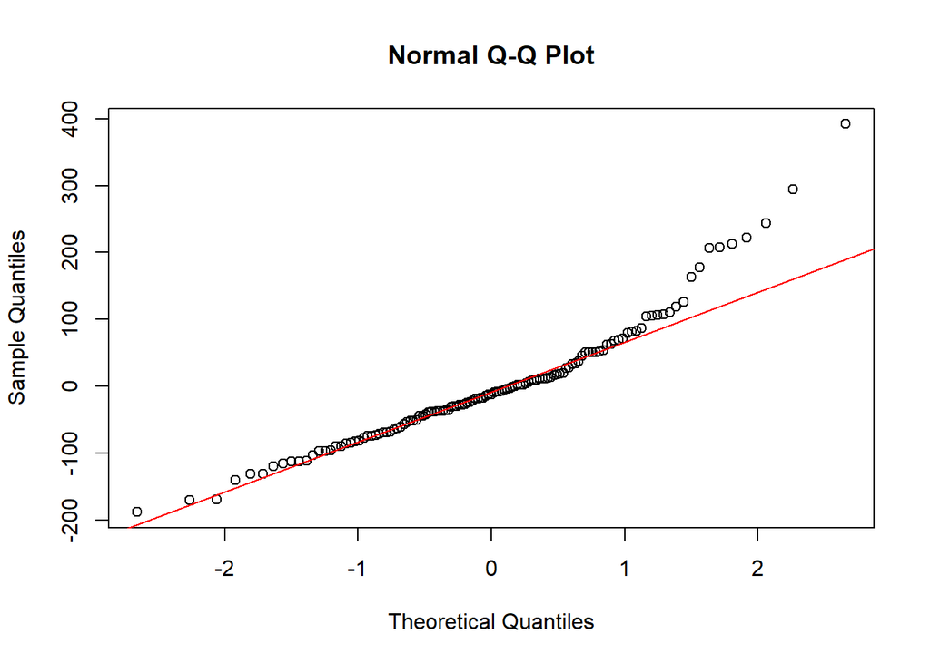

```r
e <- model1$residuals
qqnorm(e)
qqline(e, col = "red")
```

We perform the Shapiro-Wilk test to check for normality of the residuals.

```r
shapiro.test(e)
```

```
##
##  Shapiro-Wilk normality test
##
## data:  e
## W = 0.92973, p-value = 5.342e-06
```

The p-value of the Shapiro-Wilk test is less than 0.05, indicating that the residuals are not normally distributed. This once again aligns with the Q-Q plot, where the residuals have heavier tails than a normal distribution.

##### Homoscedasticity

We also perform the Breusch-Pagan test to check for homoscedasticity.

```r
bptest(model1)
```

```
##
##  studentized Breusch-Pagan test
##
## data:  model1
## BP = 10.339, df = 7, p-value = 0.1702
```

The p-value of the Breusch-Pagan test is greater than 0.05, so we fail to reject the null hypothesis of homoscedasticity. We can conclude that homoscedasticity is present.

##### Autocorrelation

We perform the Durbin-Watson test to check for autocorrelation.

```r
dwtest(model1, alternative = "two.sided")
```

```
##
##  Durbin-Watson test
##
## data:  model1
## DW = 1.9165, p-value = 0.6234
## alternative hypothesis: true autocorrelation is not 0
```

The Durbin-Watson test gives a DW value close to 2, indicating that there is no autocorrelation.

### Quadratic model

#### Plots

Consider the scatter plots between Length, Width, Height and Weights. We can see that a curve (polynomial regression) fits the data better than a linear line.

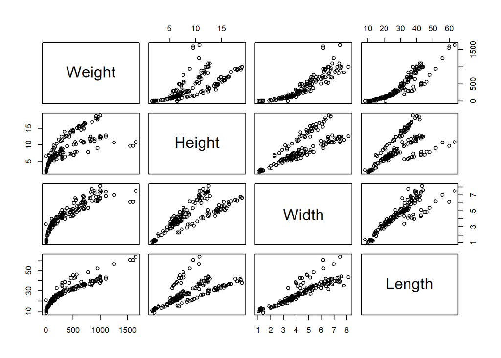

```r
pairs(subset(df, select = - Species))
```

##### Width and Weight

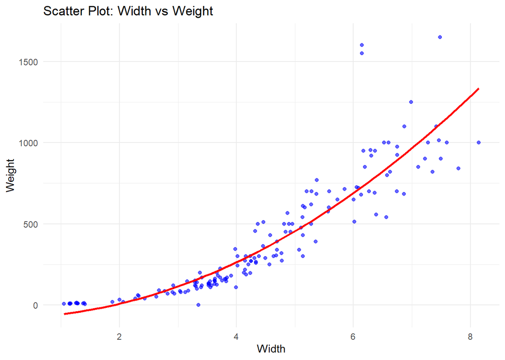

```r
ggplot(df, aes(x = Width, y = Weight)) +
  geom_point(color = "blue", alpha = 0.6) +
  geom_smooth(method = "lm", formula = y ~ I(x^2), color = "red", se = FALSE) +
  theme_minimal() +
  labs(title = "Scatter Plot: Width vs Weight", x = "Width", y = "Weight")
```

##### Length and Weight

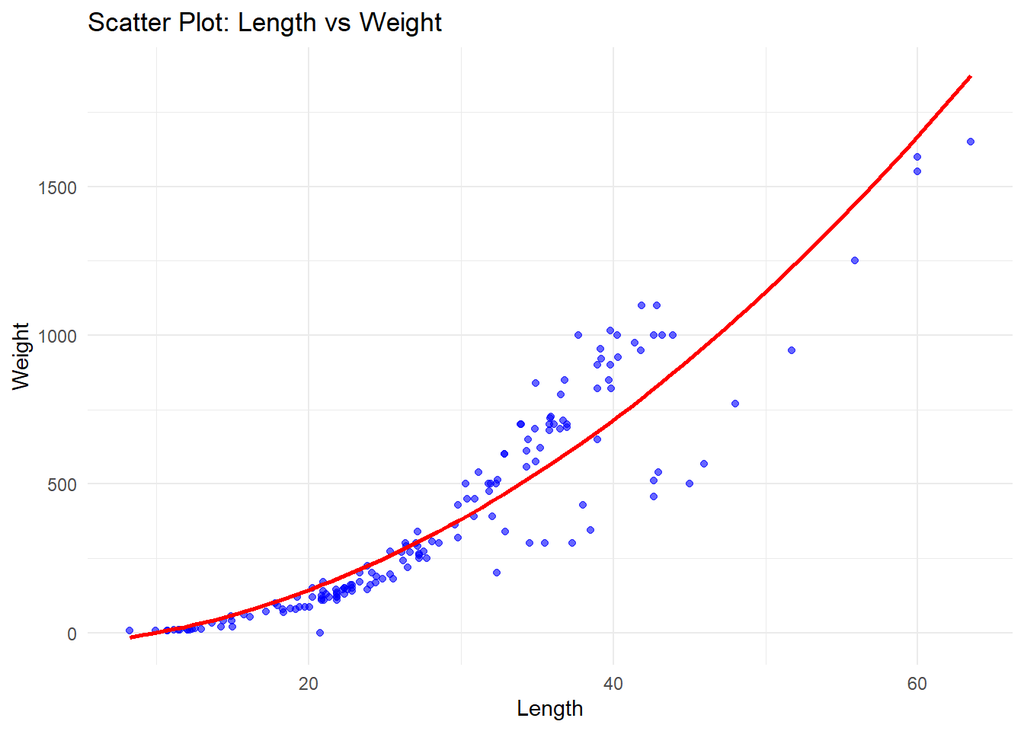

```r
ggplot(df, aes(x = Length, y = Weight)) +
  geom_point(color = "blue", alpha = 0.6) +
  geom_smooth(method = "lm", formula = y ~ I(x^2), color = "red", se = FALSE) +
  theme_minimal() +
  labs(title = "Scatter Plot: Length vs Weight", x = "Length", y = "Weight")
```

##### Height and Weight

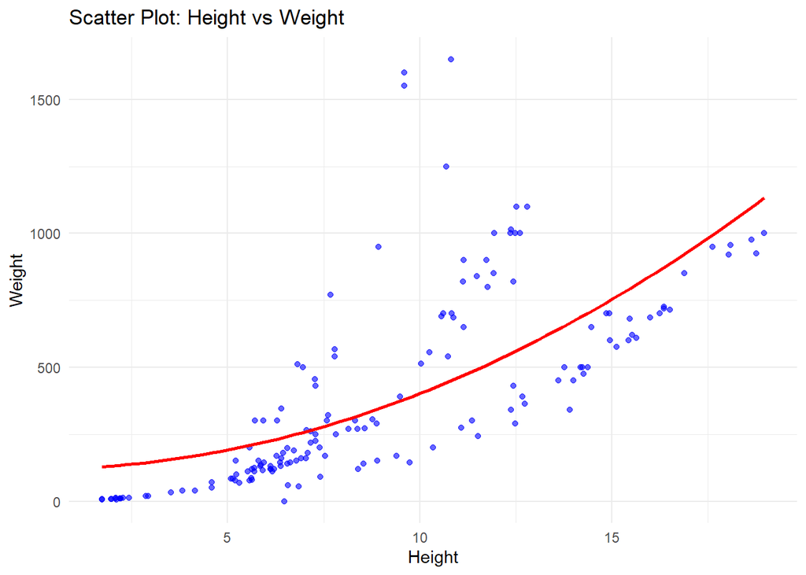

```r
ggplot(df, aes(x = Height, y = Weight)) +
  geom_point(color = "blue", alpha = 0.6) +
  geom_smooth(method = "lm", formula = y ~ I(x^2), color = "red", se = FALSE) +
  theme_minimal() +
  labs(title = "Scatter Plot: Height vs Weight", x = "Height", y = "Weight")
```

#### Selecting variables

We consider the quadratic regression model with all variables

```r
model2_baseline <- lm(Weight ~ Species + Length + Width + Height + I(Length^2) + I(Width^2) + I(Height^2) + I(Width * Height) + I(Width*Length) + I(Height*Length), data = train_set)
summary(model2_baseline)
```

```
##
## Call:
## lm(formula = Weight ~ Species + Length + Width + Height + I(Length^2) +
##     I(Width^2) + I(Height^2) + I(Width * Height) + I(Width *
##     Length) + I(Height * Length), data = train_set)
##
## Residuals:
##      Min       1Q   Median       3Q      Max
## -125.973  -16.982    0.047   16.013  122.384
##
## Coefficients:
##                     Estimate Std. Error t value Pr(>|t|)
## (Intercept)          38.7098    71.1990   0.544  0.58775
## SpeciesParkki        41.9306    26.0935   1.607  0.11091
## SpeciesPerch         65.9191    54.8689   1.201  0.23216
## SpeciesPike        -102.6617    93.1822  -1.102  0.27296
## SpeciesRoach         46.0067    48.6162   0.946  0.34604
## SpeciesSmelt         54.0289    69.9674   0.772  0.44164
## SpeciesWhitefish    113.0089    49.1007   2.302  0.02323 *
## Length              -11.2441     7.7117  -1.458  0.14765
## Width               -34.9906    47.5171  -0.736  0.46305
## Height               -1.4466    20.0683  -0.072  0.94266
## I(Length^2)           0.8400     0.1114   7.542 1.36e-11 ***
## I(Width^2)           21.1486     7.8794   2.684  0.00839 **
## I(Height^2)           0.5494     1.4997   0.366  0.71480
## I(Width * Height)     1.5883     5.8277   0.273  0.78571
## I(Width * Length)    -4.5858     1.8581  -2.468  0.01511 *
## I(Height * Length)    0.3124     0.9253   0.338  0.73630
## ---
## Signif. codes:  0 '***' 0.001 '**' 0.01 '*' 0.05 '.' 0.1 ' ' 1
##
## Residual standard error: 43.08 on 111 degrees of freedom
## Multiple R-squared:  0.9877, Adjusted R-squared:  0.986
## F-statistic:   593 on 15 and 111 DF,  p-value: < 2.2e-16
```

We perform stepwise search to remove insignificant variables.

```r
model2 <- step(model2_baseline, direction = "backward")
```

```
## Start:  AIC=970.72
## Weight ~ Species + Length + Width + Height + I(Length^2) + I(Width^2) +
##     I(Height^2) + I(Width * Height) + I(Width * Length) + I(Height *
##     Length)
##
##                      Df Sum of Sq    RSS     AIC
## - Height              1        10 206024  968.73
## - I(Width * Height)   1       138 206152  968.81
## - I(Height * Length)  1       212 206226  968.85
## - I(Height^2)         1       249 206263  968.88
## - Width               1      1006 207021  969.34
## <none>                            206014  970.72
## - Length              1      3946 209960  971.13
## - I(Width * Length)   1     11305 217319  975.51
## - I(Width^2)          1     13371 219385  976.71
## - Species             6     44233 250247  983.42
## - I(Length^2)         1    105562 311576 1021.26
##
## Step:  AIC=968.73
## Weight ~ Species + Length + Width + I(Length^2) + I(Width^2) +
##     I(Height^2) + I(Width * Height) + I(Width * Length) + I(Height *
##     Length)
##
##                      Df Sum of Sq    RSS     AIC
## - I(Width * Height)   1       137 206161  966.81
## - I(Height * Length)  1       202 206226  966.85
## - I(Height^2)         1       242 206265  966.88
## - Width               1      1273 207297  967.51
## <none>                            206024  968.73
## - Length              1      4641 210665  969.56
## - I(Width * Length)   1     11794 217818  973.80
## - I(Width^2)          1     13362 219385  974.71
## - Species             6     46407 252431  982.53
## - I(Length^2)         1    107664 313688 1020.12
##
## Step:  AIC=966.81
## Weight ~ Species + Length + Width + I(Length^2) + I(Width^2) +
##     I(Height^2) + I(Width * Length) + I(Height * Length)
##
##                      Df Sum of Sq    RSS     AIC
```

[output cut: 21 more lines]

```
## - I(Height^2)        1     83142 289666 1006.00
## - I(Length^2)        1    109197 315721 1016.94
##
## Step:  AIC=964.85
## Weight ~ Species + Length + I(Length^2) + I(Width^2) + I(Height^2) +
##     I(Width * Length)
##
##                     Df Sum of Sq    RSS     AIC
## <none>                           209487  964.85
## - I(Width * Length)  1     12723 222210  970.33
## - I(Width^2)         1     27720 237207  978.63
## - Length             1     52394 261881  991.20
## - Species            6     79436 288923  993.68
## - I(Height^2)        1     90774 300260 1008.56
## - I(Length^2)        1    127656 337142 1023.28
```

```r
summary(model2)
```

```
##
## Call:
## lm(formula = Weight ~ Species + Length + I(Length^2) + I(Width^2) +
##     I(Height^2) + I(Width * Length), data = train_set)
##
## Residuals:
##      Min       1Q   Median       3Q      Max
## -119.166  -17.869    0.418   15.767  130.917
##
## Coefficients:
##                   Estimate Std. Error t value Pr(>|t|)
## (Intercept)         3.5055    51.8219   0.068 0.946185
## SpeciesParkki      47.5084    25.0655   1.895 0.060554 .
## SpeciesPerch       74.4847    29.8519   2.495 0.014010 *
## SpeciesPike       -84.4980    42.1874  -2.003 0.047538 *
## SpeciesRoach       54.3702    29.0487   1.872 0.063790 .
## SpeciesSmelt       86.2945    34.4870   2.502 0.013747 *
## SpeciesWhitefish  121.4239    32.0891   3.784 0.000247 ***
## Length            -15.1227     2.8198  -5.363 4.28e-07 ***
## I(Length^2)         0.8659     0.1034   8.371 1.56e-13 ***
## I(Width^2)         18.4052     4.7182   3.901 0.000162 ***
## I(Height^2)         1.3390     0.1897   7.059 1.36e-10 ***
## I(Width * Length)  -3.9541     1.4962  -2.643 0.009369 **
## ---
## Signif. codes:  0 '***' 0.001 '**' 0.01 '*' 0.05 '.' 0.1 ' ' 1
##
## Residual standard error: 42.68 on 115 degrees of freedom
## Multiple R-squared:  0.9875, Adjusted R-squared:  0.9863
## F-statistic: 823.7 on 11 and 115 DF,  p-value: < 2.2e-16
```

```r
anova(model2, model2_baseline)
```

```
## Analysis of Variance Table
##
## Model 1: Weight ~ Species + Length + I(Length^2) + I(Width^2) + I(Height^2) +
##     I(Width * Length)
## Model 2: Weight ~ Species + Length + Width + Height + I(Length^2) + I(Width^2) +
##     I(Height^2) + I(Width * Height) + I(Width * Length) + I(Height *
##     Length)
##   Res.Df    RSS Df Sum of Sq      F Pr(>F)
## 1    115 209487
## 2    111 206014  4    3472.6 0.4678 0.7593
```

The p-value of the ANOVA test is much higher than the significance level of 0.05, indicating that the removed variables are not significant, and we can use the reduced model.

#### Model testing

```r
predictions <- predict(model2, newdata = test_set)
# Actual values from the test set
actual_values <- test_set$Weight
# Calculate Mean Squared Error (MSE)
mse <- mean((predictions - actual_values)^2)
# Calculate R-squared
rss <- sum((predictions - actual_values)^2)
tss <- sum((actual_values - mean(actual_values))^2)
r_squared <- 1 - (rss / tss)
# Print metrics
cat("R-squared:", r_squared, "\n")
```

```
## R-squared: 0.963937
```

#### Model diagnostics

##### Normality of residuals

We now plot the Q-Q plot of the residuals to check for normality.

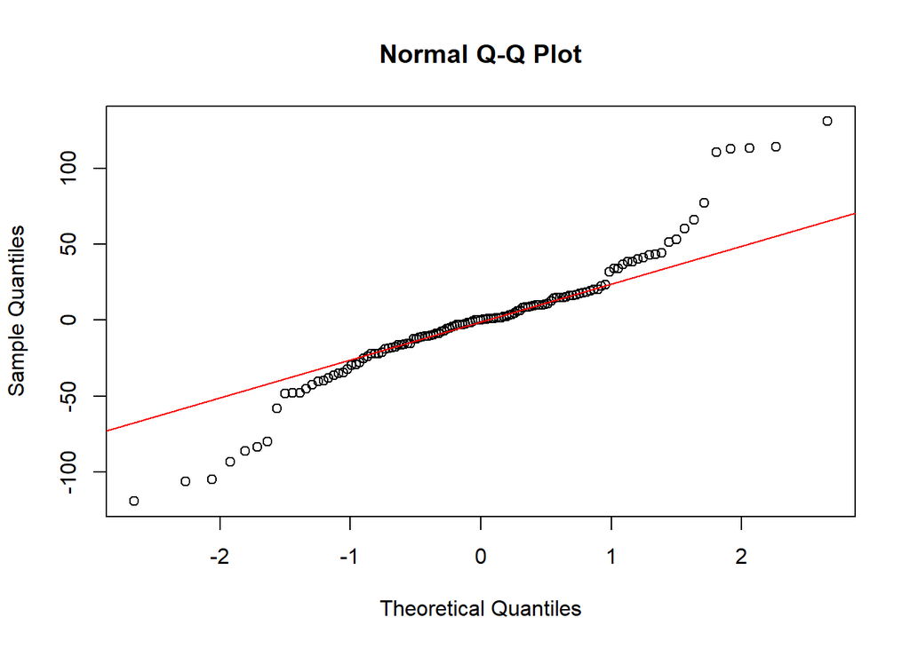

```r
e <- model2$residuals
qqnorm(e)
qqline(e, col = "red")
```

The Q-Q plot shows that most points lie close to the line in the center, but there are deviations at both ends (tails). This suggests that while the residuals are roughly normally distributed in the middle range, there are issues in the tails. This suggests that the normality assumption may not be fully satisfied.

We perform the Shapiro-Wilk test to check for normality of the residuals.

```r
shapiro.test(e)
```

```
##
##  Shapiro-Wilk normality test
##
## data:  e
## W = 0.93428, p-value = 1.057e-05
```

The p-value of the Shapiro-Wilk test is less than 0.05, indicating that the residuals are not normally distributed. This once again aligns with the Q-Q plot, where the residuals have heavier tails than a normal distribution.

##### Homoscedasticity

We also perform the Breusch-Pagan test to check for homoscedasticity.

```r
bptest(model2)
```

```
##
##  studentized Breusch-Pagan test
##
## data:  model2
## BP = 45.307, df = 11, p-value = 4.285e-06
```

The p-value of the Breusch-Pagan test is much smaller than 0.05, so we reject the null hypothesis of homoscedasticity. We can conclude that heteroscedasticity is present.

##### Autocorrelation

We perform the Durbin-Watson test to check for autocorrelation.

```r
dwtest(model2, alternative = "two.sided")
```

```
##
##  Durbin-Watson test
##
## data:  model2
## DW = 2.0726, p-value = 0.6899
## alternative hypothesis: true autocorrelation is not 0
```

The Durbin-Watson test gives a DW value close to 2, indicating that there is no autocorrelation.

### Compare with the first model

```r
anova(model1, model2)
```

```
## Analysis of Variance Table
##
## Model 1: Weight ~ Species + Length
## Model 2: Weight ~ Species + Length + I(Length^2) + I(Width^2) + I(Height^2) +
##     I(Width * Length)
##   Res.Df     RSS Df Sum of Sq      F    Pr(>F)
## 1    119 1088720
## 2    115  209487  4    879234 120.67 < 2.2e-16 ***
## ---
## Signif. codes:  0 '***' 0.001 '**' 0.01 '*' 0.05 '.' 0.1 ' ' 1
```

The p-value of the ANOVA test is extremely smaller than the significance level of 0.05, indicating that the added variables into model2 are significant, and we should use model2 since model2 fits the data better.

## 2.1.5 Conclusion

In this task, we first preprocessed the data by combining the “Length” column, and changing the “Species” column to a factor. We then split the data into training and testing sets. We fitted a baseline linear regression model with all original variables to predict “Weight”.

To improve our baseline model, we **apply the observation achieved from scatter plots** between the predictors and the target to create a new model. We include the full quadratic model of (Length, Height, Width) and add the dummy variables of “Species”. Then we run the model through a backward stepwise search to keep significant variables.